# Drinking Culture: Story of Coffee and Boba

## Introduction

This data story explores the drinking habits and social activities in coffee and boba shops in the Auckland CBD. The data was collected through observational surveys and includes variables such as the drink type, activity and the time of visit.

## What Are People Drinking?

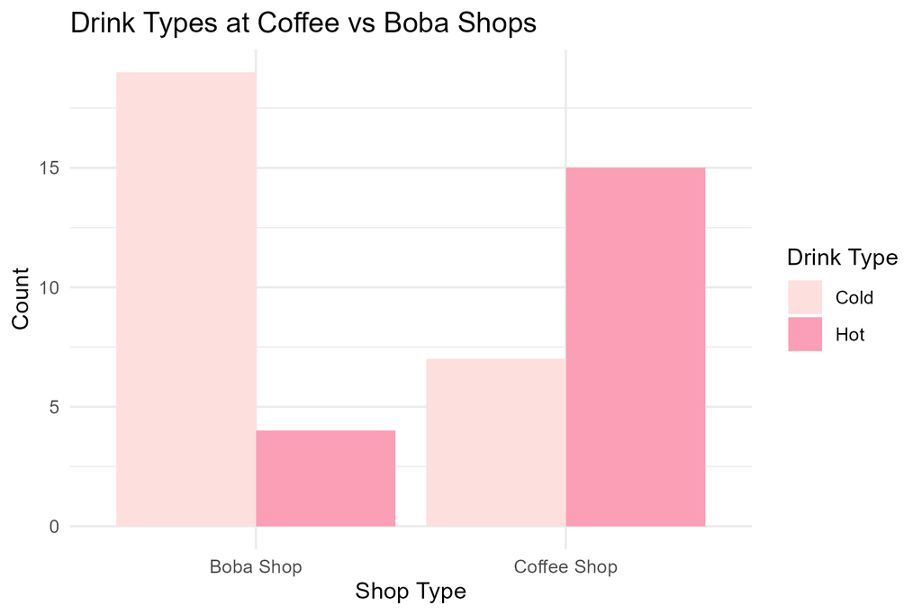

Bar chart comparing types of drinks bought at coffee vs. boba shops.

People seem to prefer different drinks depending on the shop. Coffee shops show to be more dominate with hot drinks/coffee, while boba shops are more popular when it comes to cold drinks and fruit teas.

## What Are They Doing?

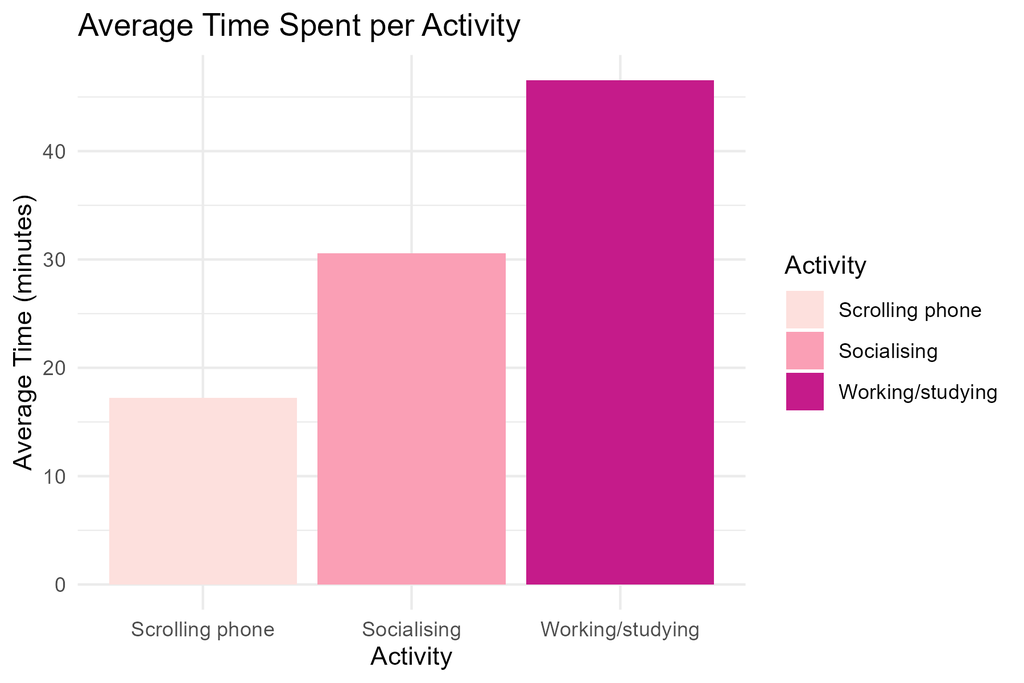

## When Do People Visit?

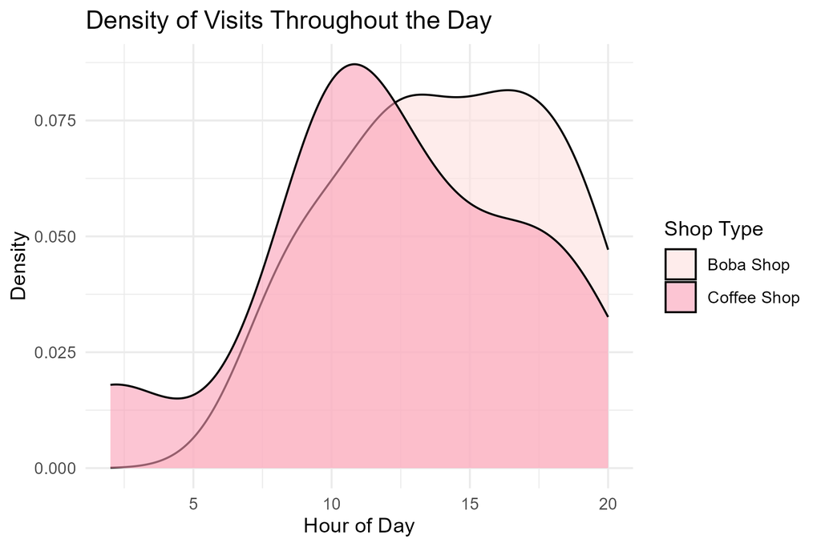

Density plot showing time of visits to coffee and boba shops.

Coffee shop traffic peaks in the morning, while boba shops start to get busier in the afternoon and evening.

## Conclusion

Drinking habits reflect much more the just beverage preferences, they can reveal how much different spaces are used whether that be just for a quick morning espresso or for a long hangout over bubble tea each drink tells its own story.